# Single dataset analysis example

```r
# Load the saved dataset
# NOTE: Alter the file path to match where you saved the dataset !
load(here::here("data", "msm-sim-study-single-simulated-dataset.rda"))

# Load needed libraries
library(dplyr)
library(gtsummary)
library(gt)
library(nnet)
library(survival)
library(ggsurvfit)
library(cobalt)
library(purrr)
library(tidyr)
library(splines)
library(lmtest)
library(sandwich)
```

```r
# Extract the wide dataset and dichotomize the time-varying confounder
# In line with the case study
# Note that the time-varying covariate is log-scale and centered
df_wide <-
  dat[["data_wide"]] |>
  mutate(
    bcr_abl1_1_bin = if_else(L_1 <= log10(50) - log10(75), 0, 1),
    bcr_abl1_2_bin = if_else(L_2 <= log10(10) - log10(75), 0, 1),
    bcr_abl1_3_bin = if_else(L_3 <= log10(10) - log10(75), 0, 1)
  )
```

# Descriptive statistics

```r
tbl_pt <-
  df_wide |>
  select(
    first_age_dx,
    spleen_size_through_imaging,
    any_cvd,
    ever_smoke
  ) |>
  tbl_summary()

tbl_trt <-
  df_wide |>
  select(starts_with("treatment_")) |>
  tbl_summary()

tbl_bcr_abl <-
  df_wide |>
  select(starts_with("bcr_") & ends_with("_bin")) |>
  tbl_summary()

tbl_stack(
  list(tbl_pt, tbl_trt, tbl_bcr_abl),
  group_header = c("Demographics", "Treatment", "BCR-ABL")
) |>
  as_gt() |>
  gt::tab_style(
    style = gt::cell_text(weight = "bold"),
    locations = gt::cells_row_groups()
  ) |>
  tab_header("Descriptive statistics")
```

Descriptive statistics

| **Characteristic** | **N = 350**<sup>1</sup> |
| --- | --- |
| Demographics |  |
| first_age_dx | 54 (43, 66) |
| spleen_size_through_imaging | 17 (11, 22) |
| any_cvd | 133 (38%) |
| ever_smoke | 173 (49%) |
| Treatment |  |
| treatment_1 |  |
| Imatinib | 178 (51%) |
| Dasatinib | 114 (33%) |
| Nilotinib | 50 (14%) |
| Others | 8 (2.3%) |
| treatment_2 |  |
| Imatinib | 32 (18%) |
| Dasatinib | 55 (31%) |
| Nilotinib | 64 (36%) |
| Others | 28 (16%) |
| Unknown | 171 |
| treatment_3 |  |
| Imatinib | 19 (21%) |
| Dasatinib | 29 (33%) |
| Nilotinib | 8 (9.0%) |
| Others | 33 (37%) |
| Unknown | 261 |
| BCR-ABL |  |
| bcr_abl1_1_bin | 270 (77%) |
| bcr_abl1_2_bin | 157 (45%) |
| bcr_abl1_3_bin | 43 (24%) |
| Unknown | 171 |

<sup>1</sup> Median (Q1, Q3); n (%)

# Overall survival descriptives

```r
os_fup <- survfit(Surv(os_yrs, (1-os_event)) ~ 1, data = df_wide)
```

Median follow-up time among survivors was 7.7 years (95% CI: 6.9 - 8.3 years). During that time, 93 patients died from any cause.

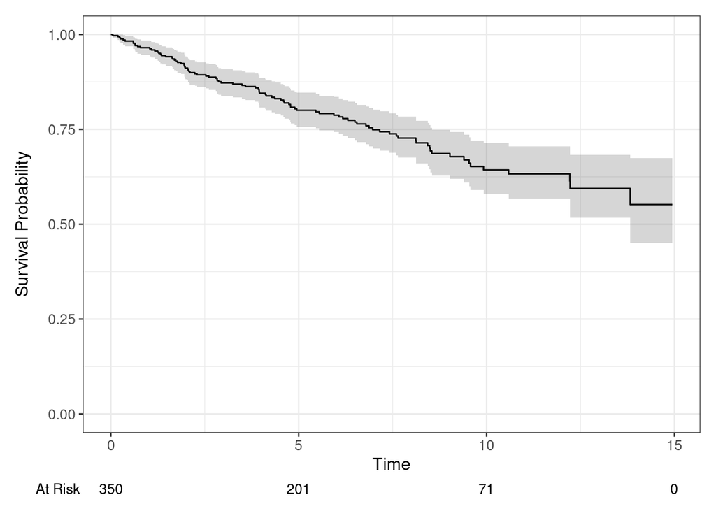

```r
# Plot of OS overall
survfit2(Surv(os_yrs, os_event) ~ 1, data = df_wide) |>
  ggsurvfit() +
  add_risktable(risktable_stats = "n.risk") +
  add_confidence_interval() +
  scale_y_continuous(limits = c(0, 1))
```

# Guidance checks

Apply the flowchart guidance.

1. Check if there are sufficient events per treatment type, across all lines

```r
# events per treatment arm, pooled over lines
events_by_arm <-
  dat[["data_long"]] |> filter(event == 1) |> count(treatment, name = "events")

events_by_arm |> gt()
```

| treatment | events |
| --- | --- |
| Imatinib | 41 |
| Dasatinib | 27 |
| Nilotinib | 12 |
| Others | 13 |

This is a very borderline case, with a 12-event arm and our guidance saying “about 10 events or more per arm”. So we will expect large margins and would need to interpret results with caution here.

2. Estimand of interest?

Marginal

# Weight models

```r
# Baseline covariates for all models
my_covs <- c(
  "first_age_dx",
  "spleen_size_through_imaging",
  "any_cvd",
  "ever_smoke"
  )
```

## Denominator weight models

```r
# Denominator model fit for line 1
denom_fit_line1 <-
  multinom(
    treatment_1 ~ first_age_dx + spleen_size_through_imaging + any_cvd +
      ever_smoke + bcr_abl1_1_bin,
    data  = df_wide,
    trace = FALSE
    )

# Denominator model fit for line 2
denom_fit_line2 <-
  multinom(
    treatment_2 ~ first_age_dx + spleen_size_through_imaging + any_cvd +
      ever_smoke + bcr_abl1_2_bin + treatment_1,
    data  = df_wide,
    trace = FALSE
    )

# Denominator model fit for line 3
denom_fit_line3 <-
  multinom(
    treatment_3 ~ first_age_dx + spleen_size_through_imaging + any_cvd +
      ever_smoke + bcr_abl1_3_bin + treatment_2,
    data  = df_wide,
    trace = FALSE
    )
```

## Numerator weight models

```r
# Numerator models (for stabilized weights)
# Marginal weights

# Numerator model fit for line 1
numer_fit_line1 <-
  multinom(
    treatment_1 ~ 1,
    data  = df_wide,
    trace = FALSE
    )

# Numerator model fit for line 2
numer_fit_line2 <-
  multinom(
    treatment_2 ~ treatment_1,
    data  = df_wide,
    trace = FALSE
    )

# Numerator model fit for line 3
numer_fit_line3 <-
  multinom(
    treatment_3 ~ treatment_2,
    data  = df_wide,
    trace = FALSE
    )
```

## Extract probabilities and compute weights

```r
# Function to extract the observed probability
get_obs_prob <- function(fit, data, treatment) {
  # probs has one row for each patient and one column for each treatment
  probs <- predict(fit, newdata = data, type = "probs")
  # lvls is the treatments
  lvls <- colnames(probs)
  # idx is a vector of indexes of which treatment the patient got,
  # relative to lvls
  idx <- match(as.character(data[[treatment]]), lvls)
  # Then extract the correct column for each row
  # Results in a vector of probabilities
  probs[cbind(seq_len(nrow(data)), idx)]
}

# Dataset limited to line 1, get numerator and denominator probs
df_line1 <-
  df_wide |>
  filter(!is.na(treatment_1)) |>
  mutate(
    p_denom = get_obs_prob(denom_fit_line1, pick(everything()), "treatment_1"),
    p_numer = get_obs_prob(numer_fit_line1, pick(everything()), "treatment_1"),
    line = 1,
    yrs_to_trt_start = 0
    )

# Dataset limited to line 2, get numerator and denominator probs
df_line2 <-
  df_wide |>
  filter(!is.na(treatment_2)) |>
  mutate(
    p_denom = get_obs_prob(denom_fit_line2, pick(everything()), "treatment_2"),
    p_numer = get_obs_prob(numer_fit_line2, pick(everything()), "treatment_2"),
    line = 2,
    yrs_to_trt_start = interval_length_1
    )

# Dataset limited to line 3, get numerator and denominator probs
df_line3 <-
  df_wide |>
  filter(!is.na(treatment_3)) |>
  mutate(
    p_denom = get_obs_prob(denom_fit_line3, pick(everything()), "treatment_3"),
    p_numer = get_obs_prob(numer_fit_line3, pick(everything()), "treatment_3"),
    line = 3,
    yrs_to_trt_start = interval_length_1 + interval_length_2
    )

# Combine the three lines and compute the standardized weights for all
df_long_wgts <-
  bind_rows(
    df_line1 |>
      rename(tki_type = treatment_1) |>
      select(-treatment_2, -treatment_3),
    df_line2 |>
      rename(tki_type = treatment_2) |>
      select(-treatment_1, -treatment_3),
    df_line3 |>
      rename(tki_type = treatment_3) |>
      select(-treatment_1, -treatment_2)) |>
    arrange(patient_id, line) |>
  # First calculate the per-line stabilized weights
  mutate(
    sw_k = p_numer / p_denom
    ) |>
  # Then do per-line truncation at the 99th percentile
  group_by(line) |>
  mutate(
    sw_trunc = pmin(sw_k, quantile(sw_k, 0.99))
    ) |>
  group_by(patient_id) |>
  mutate(
    # Then get the cumulative product within person
    sw = cumprod(sw_trunc),
    # And add prior treatment
    prior_tki_type = lag(tki_type)
  ) |>
  ungroup() |>
  mutate(
    tki_type = relevel(factor(tki_type), ref = "Imatinib") # Imatinib = reference
    )
```

## Weight diagnostics

```r
fits <- list(
  den1 = denom_fit_line1,
  den2 = denom_fit_line2,
  den3 = denom_fit_line3)

fit_tab <-
  data.frame(
  line         = 1:3,
  n            = sapply(fits, \(f) nrow(f$fitted.values)),
  params       = sapply(fits, \(f) length(coef(f))),
  max_abs_coef = sapply(fits, \(f) max(abs(coef(f)))),
  converged    = sapply(fits, \(f) f$convergence == 0)
)

wt_tab <-
  df_long_wgts |>
  group_by(line) |>
  summarise(mean_sw = mean(sw_k), max_sw = max(sw),
            ess = sum(sw)^2 / sum(sw^2), ess_prop = ess / n(),
            min_cell = min(table(tki_type)))

diag_tab <- left_join(fit_tab, wt_tab, by = "line") |>
  mutate(
    across(c(max_abs_coef, mean_sw, max_sw, ess), \(x) sprintf("%.2f", x)),
    ess_prop  = sprintf("%.2f", ess_prop),
    converged = ifelse(converged, "Yes", "No")
  ) |>
  select(line, n, params, max_abs_coef, converged,
         mean_sw, max_sw, ess, ess_prop, min_cell)

diag_tab |> gt()
```

| line | n | params | max_abs_coef | converged | mean_sw | max_sw | ess | ess_prop | min_cell |
| --- | --- | --- | --- | --- | --- | --- | --- | --- | --- |
| 1 | 350 | 18 | 2.95 | Yes | 1.00 | 2.06 | 325.56 | 0.93 | 8 |
| 2 | 179 | 27 | 20.14 | Yes | 0.98 | 3.51 | 137.31 | 0.77 | 28 |
| 3 | 89 | 27 | 18.45 | Yes | 1.00 | 5.41 | 51.37 | 0.58 | 8 |

The max_abs_coef for lines 2 and 3 are for the two empty treatment-history cells.

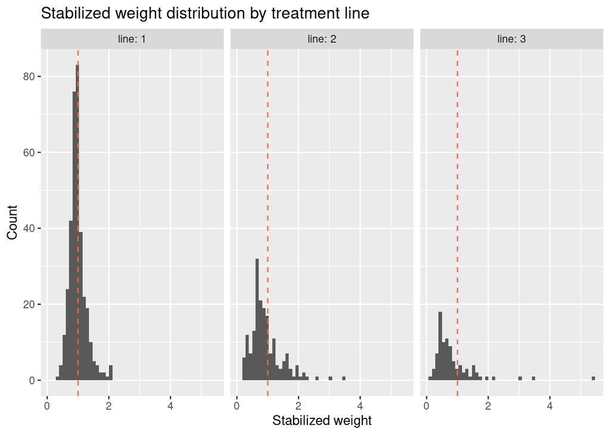

```r
# Plot the distribution of stabilized weights by line with a histogram
df_long_wgts |>
  ggplot(aes(x = sw)) +
  geom_histogram(bins = 50) +
  facet_wrap(~ line, labeller = label_both) +
  geom_vline(xintercept = 1, linetype = "dashed", color = "tomato") +
  labs(title = "Stabilized weight distribution by treatment line",
       x = "Stabilized weight", y = "Count")
```

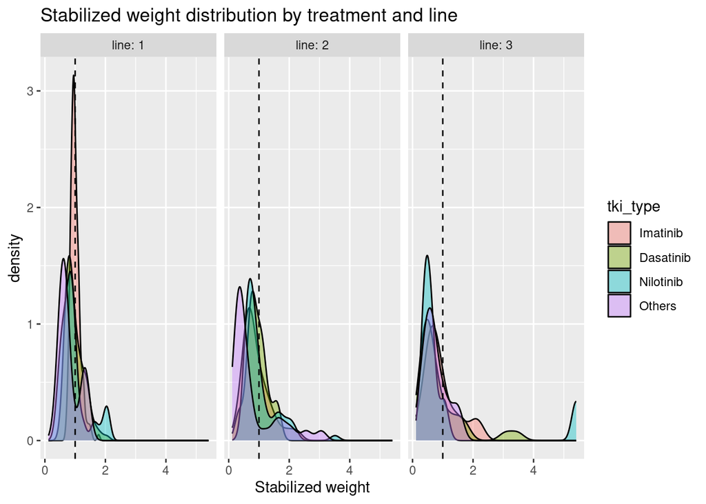

```r
# Plot the density of the stabilized weights by line and by treatment
df_long_wgts |>
  ggplot(aes(x = sw, fill = tki_type)) +
  geom_density(alpha = 0.4) +
  facet_wrap(~ line, labeller = label_both) +
  geom_vline(xintercept = 1, linetype = "dashed") +
  labs(title = "Stabilized weight distribution by treatment and line",
       x = "Stabilized weight")
```

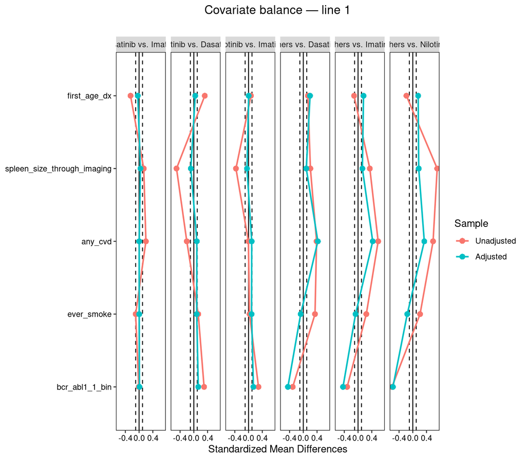

```r
# Create a love plot for line 1 to examine balance in baseline covariates before and after weighting, based on truncated weights
df_line1_wgts <- df_long_wgts |> filter(line == 1)

bal_out1 <-
  bal.tab(
    x = df_line1_wgts |>
      select(all_of(my_covs), "bcr_abl1_1_bin"),
    treat = df_line1_wgts$tki_type,
    weights = df_line1_wgts$sw,
    s.d.denom = "pooled",
    un = TRUE,
    focal = "Imatinib",
    which.treat = .all,
    binary = "std"
    )

love.plot(
  bal_out1,
  threshold = 0.1,
  line = TRUE,
  stars = "std",
  title     = "Covariate balance — line 1"
)
```

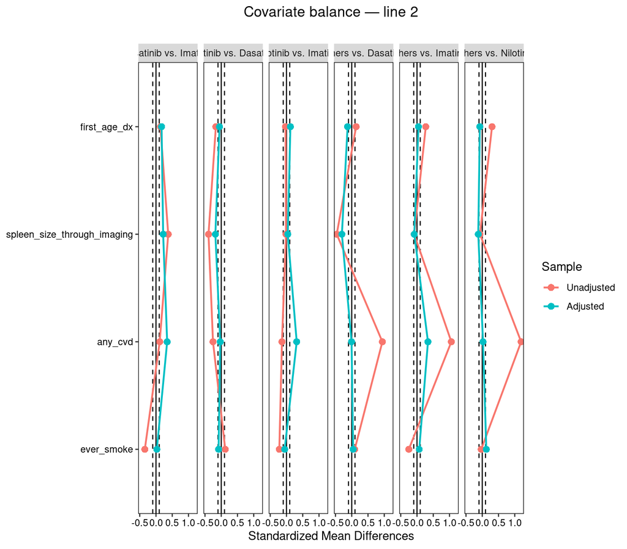

```r
# Create a love plot for line 2 to examine balance in baseline covariates before and after weighting, based on truncated weights
df_line2_wgts <- df_long_wgts |> filter(line == 2)

bal_out2 <-
  bal.tab(
    x = df_line2_wgts |>
      select(all_of(my_covs)),
    treat = df_line2_wgts$tki_type,
    weights = df_line2_wgts$sw,
    s.d.denom = "pooled",
    un = TRUE,
    focal = "Imatinib",
    which.treat = .all,
    binary = "std"
    )

love.plot(
  bal_out2,
  threshold = 0.1,
  line = TRUE,
  stars = "std",
  title     = "Covariate balance — line 2"
)
```

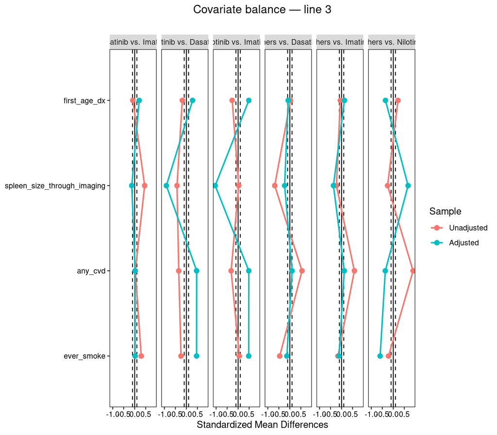

```r
# Create a love plot for line 3 to examine balance in baseline covariates before and after weighting, based on truncated weights
df_line3_wgts <- df_long_wgts |> filter(line == 3)

bal_out3 <-
  bal.tab(
    x = df_line3_wgts |>
      select(all_of(my_covs)),
    treat = df_line3_wgts$tki_type,
    weights = df_line3_wgts$sw,
    s.d.denom = "pooled",
    un = TRUE,
    focal = "Imatinib",
    which.treat = .all,
    binary = "std"
    )

love.plot(
  bal_out3,
  threshold = 0.1,
  line = TRUE,
  stars = "std",
  title     = "Covariate balance — line 3"
)
```

# Outcome models

We create two formats of data - counting process and person-period - for use in the outcome models. The counting process format is used for the Cox model, and the person-period format is used for the pooled logistic regression model.

```r
# 1. counting-process data: one row per patient-line
cp <-
  df_long_wgts |>
  arrange(patient_id, line) |>
  group_by(patient_id) |>
  mutate(
    tstart = yrs_to_trt_start,
    # next line starts, or follow-up ends
    tstop  = pmin(coalesce(lead(yrs_to_trt_start), os_yrs), os_yrs),
    # event only on the final interval
    event  = as.integer(os_event == 1 & tstop == os_yrs)
  ) |>
  ungroup() |>
  filter(tstop > tstart)

# 2. person-period data: monthly periods within each line
h <- 1 / 12
pp <- cp |>
  mutate(n_per = pmax(ceiling((tstop - tstart) / h - 1e-8), 1)) |>
  uncount(n_per, .id = "m", .remove = FALSE) |>
  mutate(
    p_start = tstart + (m - 1) * h,
    p_stop  = pmin(tstart + m * h, tstop),
    t_mid   = (p_start + p_stop) / 2,
    y       = as.integer(event == 1 & m == n_per)
  )
```

```r
# marginal (weighted), treatment only
# ns() is the spline for time
plr_marg <- glm(y ~ ns(t_mid, df = 4) + tki_type,
                family = quasibinomial, data = pp, weights = sw)
cox_marg <- coxph(Surv(tstart, tstop, event) ~ tki_type,
                  data = cp, weights = sw, cluster = patient_id)

# unweighted comparator, with baseline covariates
plr_unw <- glm(reformulate(c("ns(t_mid, df = 4)", "tki_type", my_covs), "y"),
               family = quasibinomial, data = pp)
cox_unw <- coxph(reformulate(c("tki_type", my_covs, "cluster(patient_id)"),
                             "Surv(tstart, tstop, event)"), data = cp)
```

## Results tables

First we examine the model results for the marginal weighted model, fitted by pooled logistic regression, and the conditional unweighted model, fitted by Cox regression. We report the log(OR) or log(HR) and its standard error, 95% CI, and p-value for each treatment vs Imatinib comparison.

```r
arms <- c("Dasatinib", "Nilotinib")

# cluster-robust SEs for the pooled logistic fit
plr_ct <- coeftest(plr_marg, vcov = vcovCL(plr_marg, cluster = pp$patient_id))
cox_ct <- summary(cox_unw)$coefficients
rows   <- paste0("tki_type", arms)

res <- bind_rows(
  tibble(model = "Marginal, weighted (PLR)", arm = arms,
         est = plr_ct[rows, "Estimate"], se = plr_ct[rows, "Std. Error"],
         p   = plr_ct[rows, "Pr(>|z|)"]),
  tibble(model = "Unweighted, adjusted (Cox)", arm = arms,
         est = cox_ct[rows, "coef"], se = cox_ct[rows, "robust se"],
         p   = cox_ct[rows, "Pr(>|z|)"])
)

model_tab <- res |>
  mutate(
    lo = est - qnorm(0.975) * se,
    hi = est + qnorm(0.975) * se,
    `Treatment vs Imatinib` = arm,
    Model          = model,
    `log(HR)/log(OR) (SE)` = sprintf("%.2f (%.2f)", est, se),
    `HR/OR (95% CI)`  = sprintf("%.2f (%.2f, %.2f)", exp(est), exp(lo), exp(hi)),
    `p-value`      = ifelse(p < 0.001, "<0.001", sprintf("%.3f", p))
  ) |>
  arrange(factor(arm, arms), model) |>
  select(
    `Treatment vs Imatinib`,
    Model,
    `log(HR)/log(OR) (SE)`,
    `HR/OR (95% CI)`,
    `p-value`)

model_tab |> gt()
```

| Treatment vs Imatinib | Model | log(HR)/log(OR) (SE) | HR/OR (95% CI) | p-value |
| --- | --- | --- | --- | --- |
| Dasatinib | Marginal, weighted (PLR) | -0.41 (0.26) | 0.66 (0.40, 1.11) | 0.118 |
| Dasatinib | Unweighted, adjusted (Cox) | -0.34 (0.26) | 0.71 (0.43, 1.19) | 0.195 |
| Nilotinib | Marginal, weighted (PLR) | -0.58 (0.39) | 0.56 (0.26, 1.22) | 0.143 |
| Nilotinib | Unweighted, adjusted (Cox) | -0.71 (0.35) | 0.49 (0.25, 0.97) | 0.040 |

We also examine the number of events and the expected versus observed SEE.

```r
d_ref <- events_by_arm$events[events_by_arm$treatment == "Imatinib"]
events_tab <- events_by_arm |>
  filter(treatment %in% arms) |>
  mutate(ref_events = d_ref,
         expected_see = 1.1 * sqrt(1 / events + 1 / ref_events),
         observed_see = res$se[res$model == "Marginal, weighted (PLR)"][match(treatment, res$arm[res$model == "Marginal, weighted (PLR)"])],
         ci_fold = exp(2 * qnorm(0.975) * expected_see))
events_tab |> gt() |> fmt_number(c(expected_see, observed_see, ci_fold), decimals = 2)
```

| treatment | events | ref_events | expected_see | observed_see | ci_fold |
| --- | --- | --- | --- | --- | --- |
| Dasatinib | 27 | 41 | 0.27 | 0.26 | 2.91 |
| Nilotinib | 12 | 41 | 0.36 | 0.39 | 4.12 |